# Personal-academic Project

# 3 Example 2

## 3.1 Analysis applying DBSCAN and OPTICS methods.

Based on the same dataset that has been created, including the normalized scores, we will proceed to perform an analysis using DBSCAN and OPTICS.

We will use the ‘DBSCAN’ library, which focuses on efficiently implementing DBSCAN and OPTICS. Additionally, we will complement it with the use of the ‘fpc’ library, which includes a ‘cluster.stats’ function that can evaluate the results of an OPTICS clustering.

OPTICS (Ordering Points to Identify the Clustering Structure), introduced by Ankerst et al. in 1999, is an extension of the DBSCAN algorithm that can help us better handle the problem of variable density among clusters, which was evident when applying k-means. OPTICS does not directly assign clusters but orders the points to highlight their density, facilitating visualization with a reachability plot that shows the distance between each point. While theoretically, we do not have outliers in the dataset, if present, OPTICS does not exclude outliers but identifies them by assigning them a higher reachability value.

Let’s proceed with OPTICS:

```r
print("aplicamos optics al dataset que ya tenemos")
```

```
## [1] "aplicamos optics al dataset que ya tenemos"
```

```r
# Configuramos eps= x o la distancia máxima entre dos puntos:
# El grupo debe tener como mínimo 'minPts'= x observaciones para ser agrupado

optics_result <- dbscan::optics(hawks_z, minPts = 10)
optics_result
```

```
## OPTICS ordering/clustering for 908 objects.
## Parameters: minPts = 10, eps = 3.07716556342231, eps_cl = NA, xi = NA
## Available fields: order, reachdist, coredist, predecessor, minPts, eps,
##                   eps_cl, xi
```

```r
# Obtenemos el orden de las observaciones o puntos
print("Obtenemos la odenacion de los puntos")
```

```
## [1] "Obtenemos la odenacion de los puntos"
```

```r
optics_result$order
```

```
##   [1]   1 571 390 267 260 245 620 185 184 150 149 137  93 824 764 650 408 233
##  [19] 193  25 236 487 481 426 378 317 787 771 594 467 281  12  87 134 119 278
##  [37] 203 765 334 861 844 701 471 223 283 116 648 891 832 707 681 547 508 337
##  [55] 762 579 139 251  80   7 165 555 365 532 131  11 402 784 295 364 206 515
##  [73] 457 876 561 550 391  33 222 774 717 552 292 403 372 250 823 506 460 179
##  [91] 154  48  43 758 589 871 848 671 450  79 898 760 473   3 113 715 423 483
## [109] 438 427 270 647 135  90  31 696 782 740 590 182 323 190 157 342 800 465
## [127] 338 180 178 679 181 354 556 778 726 528 437 526  45 355 544 743 649 582
## [145] 336 155 855 309 615 854 893 169 433 274 585 240 110  21 572 183 692 862
## [163]   2  51 286 789 733 324 719 846 560 505 478 867 878 576 466 434 380 230
## [181]  19 194 853 489 504 114 617 136 138  71 709 258 770 290 205 237 596 780
## [199] 775 602 600 601 581 397 745 117 907 868 674 676 537  32 553 412 177 173
## [217]  49 200 672 151 559 605 606 593 881 769 496 531 888 197 159 123 385 497
## [235] 883 882 614 540 901 744 558 369 209 208 204 455 694 275 514 367 609 608
## [253] 892 812 631 566 501 405 300 224 785 199  47  72 691 207  10 294  46 153
```

[output cut: 36 more lines]

Creating a reachability diagram:

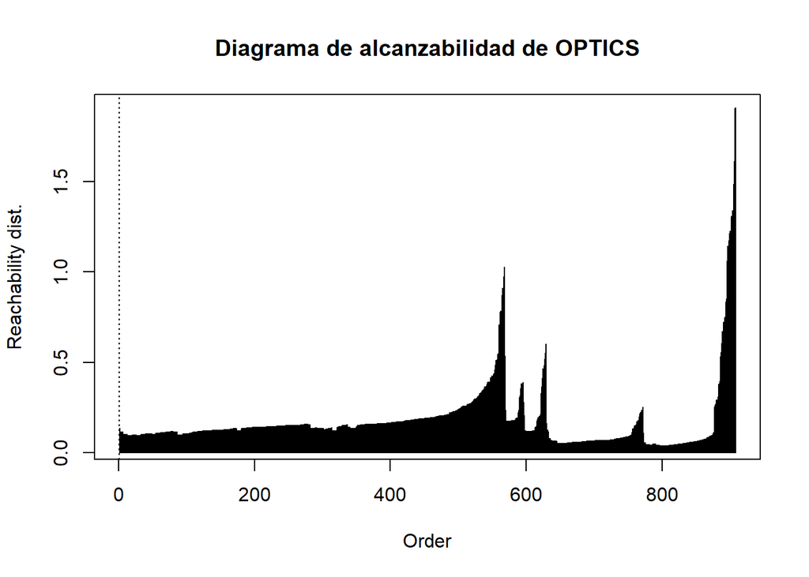

```r
# Diagrama o gráfica de alcance

plot(optics_result, main= "Diagrama de alcanzabilidad de OPTICS")
```

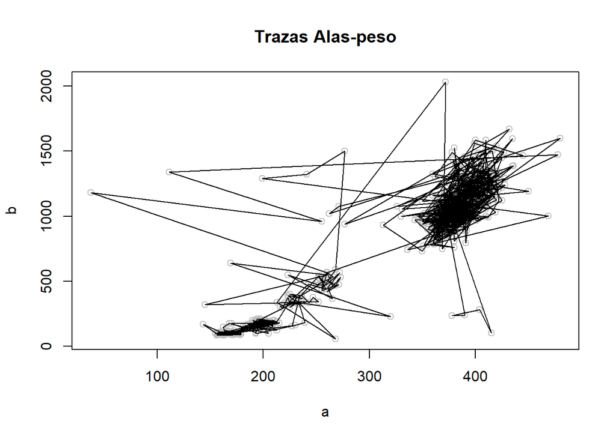

```r
## Dibujo de trazas variables alas-peso

# Selección de columnas

a <- hawks_select$Wing
b <- hawks_select$Weight
c <- hawks_select$Culmen
d <- hawks_select$Hallux

# Creación de la grafica
plot(a, b,  col="grey")

# agregamos trazos al par 'Alas-Peso'
title("Trazas Alas-peso")
polygon(a[optics_result$order],  b[optics_result$order])
```

And now the graph for the traces:

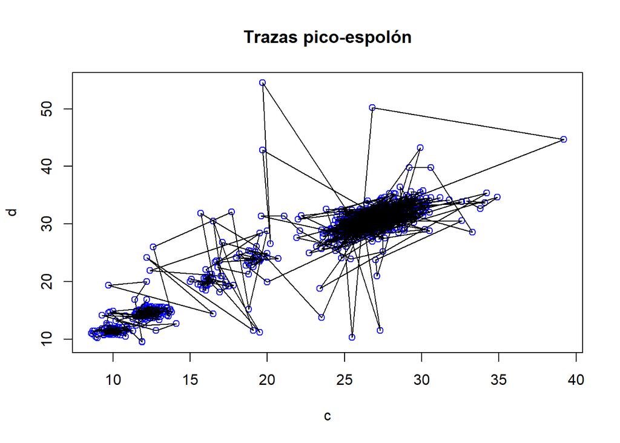

```r
# Dibujo de trazas pico-espolon

c <- hawks_select$Culmen
d <- hawks_select$Hallux

# Creación de la grafica
plot(c, d,  col="blue")

# agregamos trazos al par 'Alas-Peso'
title("Trazas pico-espolón")
polygon(c[optics_result$order],  d[optics_result$order])
```

Devtools is an R package designed to facilitate development. It provides useful functions for development tasks, especially related to package installation from the repository and version control on GitHub. It also includes features for building, loading packages, and running tests (“Tools to Make Developing R Packages Easier,” n.d.; “Function Reference,” n.d.; *Devtools* 2023).

On the other hand, ggbiplot is an R package that provides a ggplot2-based implementation of biplot graphs for prcomp(). It is particularly useful for visualizing high-dimensional data. In a biplot, both observations and variables are represented in the same two-dimensional space. However, it should be noted that ggbiplot is no longer actively maintained (Vu 2023; MYaseen208 2014).

Based on the above, it is important to note that ggbiplot is not available in the official CRAN repository and needs to be installed from GitHub using an intermediary tool like devtools.

We proceed with PCA and the plot using ggbiplot.

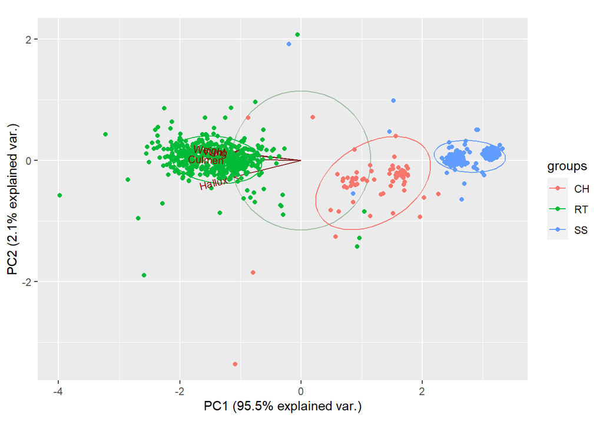

```r
# vamos a necesitar el paquete  'devtools':
if (!require('devtools')) install.packages('devtools'); library(devtools)

# usamos la función 'install_github' para la instalación de 'ggbiplot':
install_github("vqv/ggbiplot"); library(ggbiplot)


pca_result <- prcomp(hawks_select[,c("Wing", "Weight", "Culmen", "Hallux")], scale = TRUE)
pca_graph <- ggbiplot(pca_result, obs.scale = 1, var.scale = 1,
              groups = hawks_select$Species, ellipse = TRUE,
              circle = TRUE)
print(pca_graph)
```

```r
# Obtener los resultados del PCA
pca_variances <- pca_result$sdev^2
pca_proportions <- pca_variances / sum(pca_variances)
pca_loadings <- pca_result$rotation

# Imprimir los resultados
cat("Varianzas explicadas por cada componente principal:\n")
```

```
## Varianzas explicadas por cada componente principal:
```

```r
cat(pca_variances, "\n")
```

```
## 3.818186 0.08320639 0.06543398 0.03317334
```

```r
cat("\nProporciones de varianzas explicadas por cada componente principal:\n")
```

```
##
## Proporciones de varianzas explicadas por cada componente principal:
```

```r
cat(pca_proportions, "\n")
```

```
## 0.9545466 0.0208016 0.01635849 0.008293336
```

```r
cat("\nLoadings de cada variable en cada componente principal:\n")
```

```
##
## Loadings de cada variable en cada componente principal:
```

```r
print(pca_loadings)
```

```
##               PC1         PC2         PC3        PC4
## Wing   -0.4996307  0.35899878 -0.69365839  0.3746026
## Weight -0.4988718  0.40751286  0.71581475  0.2695727
## Culmen -0.5053149  0.06469731 -0.06588903 -0.8579800
## Hallux -0.4961381 -0.83717824  0.04589029  0.2255520
```

Principal Component Analysis (PCA) is a dimensionality reduction technique that allows us to visualize and understand the structure of a multidimensional dataset. In this case, we applied PCA to a dataset of hawks with four variables of interest: wing size, culmen size, hallux size, and weight.

In this analysis, PC1 explains approximately 95% of the total variance in the data. It appears that PC1 is strongly influenced by all the variables, as the loading coefficients of the variables in PC1 are relatively similar in magnitude. This suggests that the four variables are correlated, as they increase or decrease together. Hypothetically, this could be interpreted as larger hawks tending to have longer wings, higher weight, larger culmen size, and bigger hallux, which seems logical.

The remaining principal components (PC2, PC3, and PC4) explain only a small fraction of the total variance (around 4.55%). However, they can still be useful for identifying subtle patterns in the data. For example, the loading coefficient of the Hallux variable in PC2 is negative and of large magnitude, indicating that hallux length varies in the opposite direction to the other variables in this dimension. This could suggest the existence of different adaptation strategies among hawk species.

Although this is a hypothesis and beyond the scope of this work, it is an exciting discovery. By observing a large negative loading value (-0.84) for the hallux size, we find that hawks with larger hallux have smaller culmen size, shorter wings, and lower weight. Could this indicate an evolutionary advantage for birds of this species? Could it be an adaptation strategy because the smaller bird is more agile and more effective in attacking?

As PCA is an exploratory rather than inferential technique, these hypotheses should be treated with caution. However, there is no doubt that extracting such insights from this unintelligible amalgamation of information is highly exciting. The patterns identified in this analysis need to be confirmed with further studies. Other data analysis techniques, such as clustering analysis, could be applied to identify groups of hawks with similar characteristics or to study hunting behavior. In any case, the results open up new questions that should be confirmed with other types of inferential studies.

At this point, we consider that there is “noise” in the dataset, variables that tend to confuse the model. We cannot consider these outliers, as we have mathematically shown - we believe. Before continuing with the analysis, an interesting option would be to use DBSCAN, as the groups are neither “spherical” nor have similar shapes, and it is clear that centroid-based methods like k-means present problems.

Therefore, we will analyze the dataset using DBSCAN:

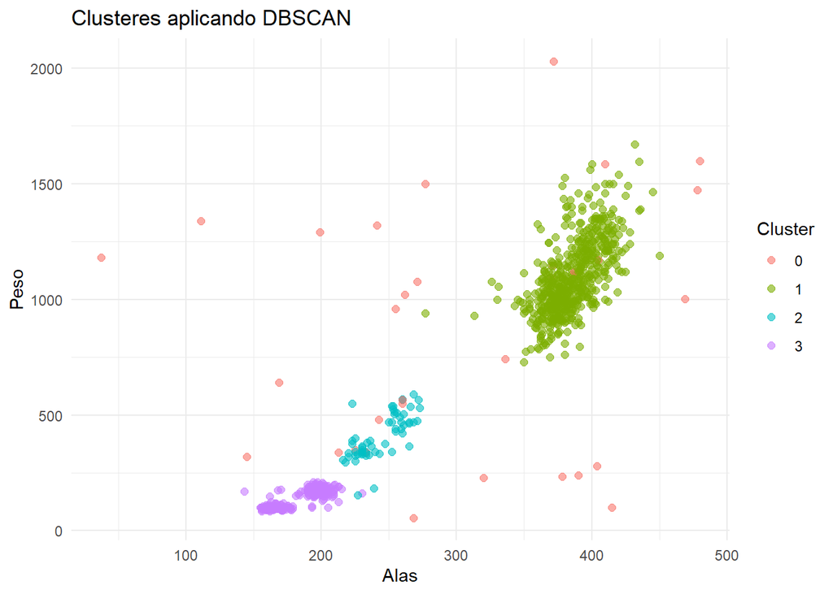

```r
# Aplicando DBSCAN en terminos parecidos a la aplicación de OPTICS de partida, pero vamos probando hasta encontrar el mas optimo posible
dbscan_result <- dbscan(hawks_z, eps= 0.5, minPts = 5)

# Agregamos el resultado al DF principal. Aprovechamos para agregar OPTICS tambien e integrar resultados:

# Agregamos a los datos el resultado de DBSCAN
hawks_select$Dbscan_cluster <- as.factor(dbscan_result$cluster)

# agregamos a los datos el resultado de OPTICS
hawks_select$Optics_order <- as.factor(optics_result$order)

# Graficamos los clusteres en un 'scatter plot' utilizando 'Wing' y 'Weight'
ggplot(hawks_select, aes(x = Wing, y= Weight, color = Dbscan_cluster)) +
  theme_minimal() +
  geom_point(alpha = 0.6, size = 2) +
  labs(title = "Clusteres aplicando DBSCAN", x= "Alas", y = "Peso", color= "Cluster")
```

We observe more clearly that there are 3 distinguishable groups, where some observations have not been grouped according to the ‘minPts’ parameters.

```r
# Aplicando 'cluster.stats' ##
#################################
# cluster.stats requiere de enteros, no de factores, por lo que lo convertimos:
hawks_select$Cluster3i <- as.integer(as.character(hawks_select$Cluster3))
hawks_select$Cluster6i <- as.integer(as.character(hawks_select$Cluster6))

# Calculamos las distancias
dist_matrix <- dist(hawks_select[, c("Wing", "Weight", "Culmen", "Hallux")])

# Sacamos las estadísticas del cluster3
clust3_stats <- cluster.stats(dist_matrix, hawks_select$Cluster3i)

# Sacamos las estadísticas del cluster6
clust6_stats <- cluster.stats(dist_matrix, hawks_select$Cluster6i)


# Imprimimos las estadísticas del cluster3
print(clust3_stats)
```

```
## $n
## [1] 908
##
## $cluster.number
## [1] 3
##
## $cluster.size
## [1] 258  72 578
##
## $min.cluster.size
## [1] 72
##
## $noisen
## [1] 0
##
## $diameter
## [1]  132.5468 1147.4518 1929.4797
##
## $average.distance
## [1]  50.30685 153.64087 201.17756
##
## $median.distance
## [1]  49.7358 128.8547 160.0241
##
## $separation
## [1]  7.435725  7.435725 19.724350
##
## $average.toother
## [1] 901.5759 576.2512 918.5395
##
## $separation.matrix
##            [,1]      [,2]      [,3]
## [1,]   0.000000  7.435725 166.40379
## [2,]   7.435725  0.000000  19.72435
## [3,] 166.403786 19.724350   0.00000
##
## $ave.between.matrix
##          [,1]     [,2]     [,3]
## [1,]   0.0000 287.4075 978.0813
## [2,] 287.4075   0.0000 705.1815
```

[output cut: 53 more lines]

```
##
## $cwidegap
## [1]  25.49549 530.27966 364.97685
##
## $widestgap
## [1] 530.2797
##
## $sindex
## [1] 14.56867
##
## $corrected.rand
## NULL
##
## $vi
## NULL
```

```r
# Imprimimos las estadísticas del cluster 6
print(clust6_stats)
```

```
## $n
## [1] 908
##
## $cluster.number
## [1] 6
##
## $cluster.size
## [1] 113  34 220 145  39 357
##
## $min.cluster.size
## [1] 34
##
## $noisen
## [1] 0
##
## $diameter
## [1]   92.34766 1293.59824 1038.77856  114.28263  396.50448 1208.46738
##
## $average.distance
## [1]  15.98279 189.98254 147.29935  26.58533  74.05301 121.20192
##
## $median.distance
## [1]  11.27231  87.73374 116.79790  21.12061  46.35645  90.35535
##
## $separation
## [1] 3.238827 8.648699 2.469818 3.238827 7.435725 2.469818
##
## $average.toother
## [1] 785.6934 534.4848 667.0840 751.9300 586.3602 600.9891
##
## $separation.matrix
##            [,1]       [,2]       [,3]       [,4]       [,5]       [,6]
## [1,]   0.000000  88.332384 851.410148   3.238827  23.541028 195.674372
## [2,]  88.332384   0.000000 131.617400  78.378887   8.648699  19.724350
## [3,] 851.410148 131.617400   0.000000 810.457723 467.966292   2.469818
## [4,]   3.238827  78.378887 810.457723   0.000000   7.435725 166.403786
## [5,]  23.541028   8.648699 467.966292   7.435725   0.000000  45.824993
## [6,] 195.674372  19.724350   2.469818 166.403786  45.824993   0.000000
##
## $ave.between.matrix
```

[output cut: 59 more lines]

```
##
## $cwidegap
## [1]  38.03617 530.27966 364.97685  26.30836 111.07876 320.24625
##
## $widestgap
## [1] 530.2797
##
## $sindex
## [1] 5.367926
##
## $corrected.rand
## NULL
##
## $vi
## NULL
```

We can draw several conclusions from the results:

It appears that the first method produces clusters with a higher silhouette, while the second method identifies smaller and more compact groups. However, both methods offer subpar results overall.

We will now proceed with our analysis by applying cluster.stats to the results of DBSCAN. Unlike OPTICS, DBSCAN groups points that are close in data space and within areas of density above a threshold. It may leave some points unassigned, as we observed in the previous graph. These unassigned groups are considered noise or outliers.

Unlike OPTICS, however, DBSCAN directly provides a point-to-cluster assignment. This means that we can use cluster.stats with the results of DBSCAN to obtain various clustering metrics. However, as with OPTICS, some of the metrics provided by cluster.stats may be less relevant for a density-based clustering method like DBSCAN than for k-means. Nevertheless, it can be interesting to apply it and see the results.

```r
## Convertimos el resultado de DBSCAN a factor
clusters_dbscan <- dbscan_result$cluster
#Eliminamos los puntos de ruido que son ceros
no_noise_idx <- which(clusters_dbscan != 0)
# Conviertimos el objeto "distancias" en una matriz completa
distancias_matrix <- as.matrix(distancias)

# Aplicamos la funcion cluster.stats
dbscan_stats <- cluster.stats(distancias_matrix[no_noise_idx, no_noise_idx], clusters_dbscan[no_noise_idx])

# Impresion de los resultados
print(dbscan_stats)
```

```
## $n
## [1] 873
##
## $cluster.number
## [1] 3
##
## $cluster.size
## [1] 557  59 257
##
## $min.cluster.size
## [1] 59
##
## $noisen
## [1] 0
##
## $diameter
## [1] 2.454986 1.660387 1.302045
##
## $average.distance
## [1] 0.6726576 0.6010459 0.4207059
##
## $median.distance
## [1] 0.6129363 0.6098050 0.4548728
##
## $separation
## [1] 1.0368159 0.6010496 0.6010496
##
## $average.toother
## [1] 3.955004 2.377565 3.985860
##
## $separation.matrix
##          [,1]      [,2]      [,3]
## [1,] 0.000000 1.0368159 2.6057370
## [2,] 1.036816 0.0000000 0.6010496
## [3,] 2.605737 0.6010496 0.0000000
##
## $ave.between.matrix
##          [,1]     [,2]     [,3]
## [1,] 0.000000 2.728048 4.236678
## [2,] 2.728048 0.000000 1.617959
```

[output cut: 53 more lines]

```
##
## $cwidegap
## [1] 0.4580172 0.4829025 0.3966234
##
## $widestgap
## [1] 0.4829025
##
## $sindex
## [1] 0.7371039
##
## $corrected.rand
## NULL
##
## $vi
## NULL
```

The results obtained from the DBSCAN clustering using the cluster.stats function can be summarized as follows:

- Number of clusters: Three clusters were formed.

$cluster.number [1] 3

```r
## Extraccion de un clustering DBSCAN cortando la alcanzabilidad en el valor eps_cl
optics_result2 <- extractDBSCAN(optics_result, eps_cl = .99)
optics_result2
```

```
## OPTICS ordering/clustering for 908 objects.
## Parameters: minPts = 10, eps = 3.07716556342231, eps_cl = 0.99, xi = NA
## The clustering contains 2 cluster(s) and 13 noise points.
##
##   0   1   2
##  13 567 328
##
## Available fields: order, reachdist, coredist, predecessor, minPts, eps,
##                   eps_cl, xi, cluster
```

We plotted the results.

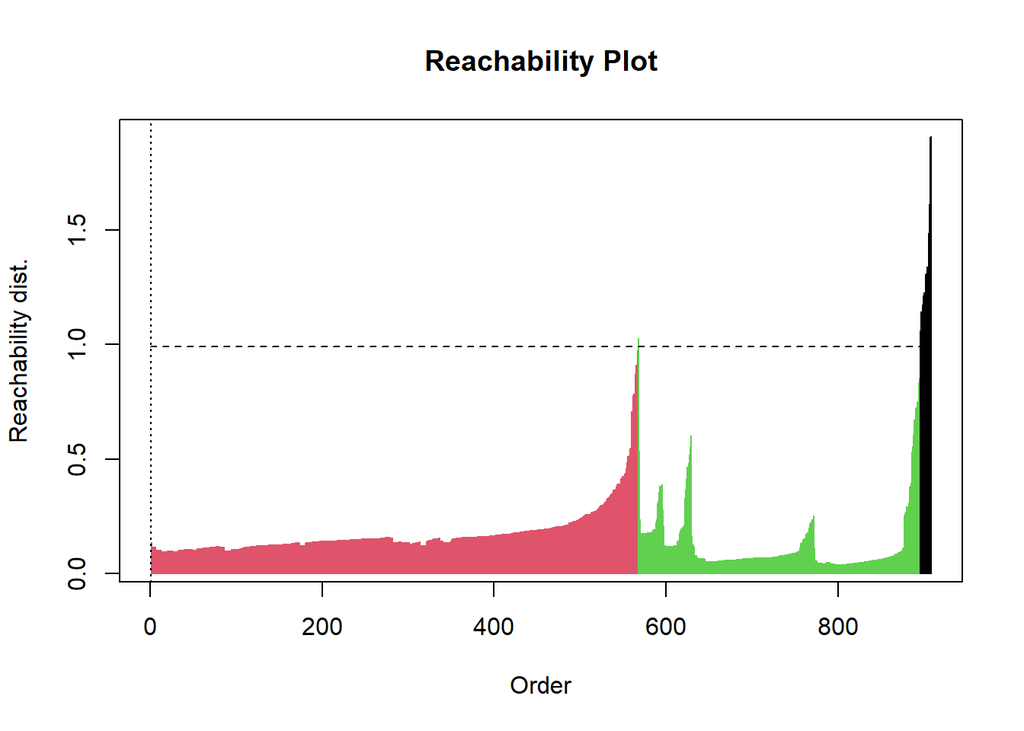

```r
# plot optics results
plot(optics_result2)
```

Another visualisation:

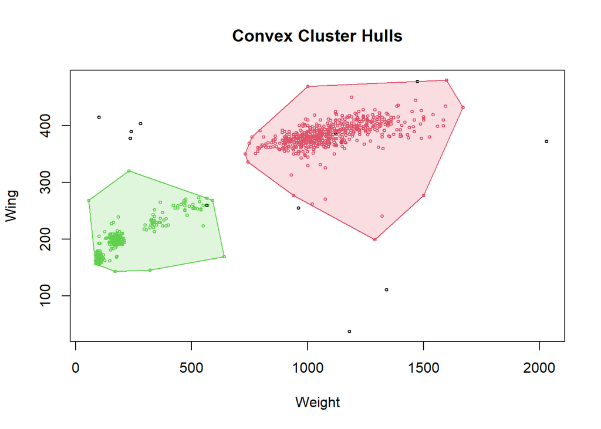

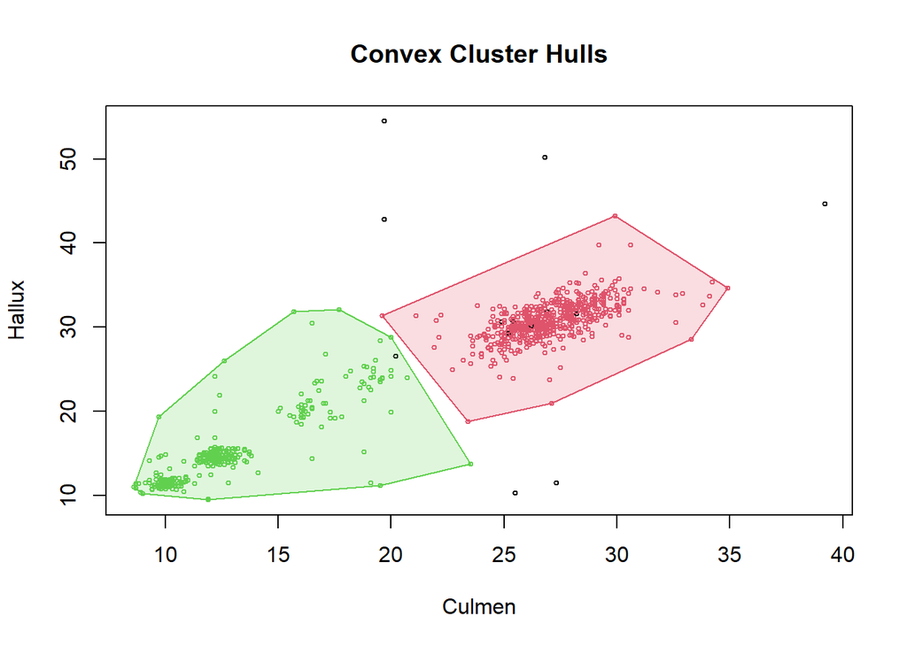

# 4 Conclusions

And at this point, we conclude the two examples. We could conclude that from the dataset, three heterogeneous clusters can be extracted, and the DBSCAN method with and without OPTICS appears to be superior to k-means for a dataset like the reference one, which has a lot of noise and data variability. However, in neither of the two cases can the results be considered satisfactory.

## 4.1 Comparison of Clustering Methods: K-means and DBSCAN

Clustering is a widely used method in data analysis to identify patterns and underlying structures. Two of the most popular clustering algorithms are K-means and DBSCAN. Each has its own strengths and weaknesses:

## 4.2 K-means

The K-means algorithm is an unsupervised prototype-based clustering method that aims to minimize the total variance within a group. It is simple and effective and has been a reference tool for decades, but with limitations. A predefined number of centroids are randomly selected, and data points are assigned to the nearest centroid or group with the closest mean. Then, the centroids are recalculated, and the process is repeated until a convergence criterion is met. This method has limitations.

It requires the prior specification of the number of clusters, which may be unknown in real-world situations.

Additionally, K-means tends to generate circular clusters and may not work well with clusters of more complex shapes or with noise, as we have seen in our dataset.

## 4.3 DBSCAN

DBSCAN (Density-Based Spatial Clustering of Applications with Noise) is a density-based clustering algorithm. It groups points together that have a sufficiently high number of points in their neighborhood and can discover clusters of non-linear shapes. DBSCAN does not require the prior specification of the number of clusters. On the downside, it is sensitive to the selection of input parameters, such as the maximum distance (eps) and the minimum number of points required to form a dense cluster (minPts). It can be challenging to interpret its results, especially in cases where clusters are close and exhibit density variations. This requires experience and time to fine-tune or refine the model. Additionally, DBSCAN’s dependency on the Euclidean distance measure can be a disadvantage in high-dimensional datasets, where the curse of dimensionality can distort distances between points.

We have also explored the OPTICS algorithm, which can be considered an extension of DBSCAN. It addresses the limitations of DBSCAN in terms of identifying clusters with variable density. With OPTICS, it is possible to graphically represent the clustering results and extract clusters from a hierarchy of densities, which is useful in contexts where clustering patterns are not initially evident.

## 4.4 Comparison of Results

In our analysis, we applied both methods (or multiple methods) to a dataset of birds of prey and compared the results. Each of these algorithms has provided valuable insights.

Both methods can be useful tools for data clustering, but their performance may vary depending on the characteristics of the dataset, especially with real-world data that exhibit high variance and high levels of noise, as in the case developed in this work. The choice between different techniques is part of the data scientist’s work. The selection of the clustering algorithm should be guided by the nature of the dataset and the research questions, so it is vital to understand the strengths and weaknesses of each technique or method.

# BIBLIOGRAPHY

Cannon, Ann, George Cobb, Bradely Hartlaub, Julie Legler, Robin Lock, Thomas Moore, Allan Rossman, and Jeffrey Witmer. 2013a. “STAT2: Building Models for a World of Data.” *Faculty & Staff Scholarship*, January. https://digitalcommons.oberlin.edu/faculty_schol/3269.

———. 2013b. “STAT2: Building Models for a World of Data.” *Faculty & Staff Scholarship*, January. https://digitalcommons.oberlin.edu/faculty_schol/3269.

*Devtools*. 2023. R infrastructure. https://github.com/r-lib/devtools.

“Digital Commons at Oberlin.” n.d. https://digitalcommons.oberlin.edu/.

“Function Reference.” n.d. https://devtools.r-lib.org/reference/index.html.

Gareth, James, Witten Daniela, Hastie Trevor, and Tibshirani Robert. 2013. *An Introduction to Statistical Learning: With Applications in r*. Spinger.

Gironés Roig, Jordi. 2017. “Minería de Datos : Modelos y Algoritmos.” *Minería de Datos*, 1–273. https://www.torrossa.com/en/resources/an/4234044.

James, Gareth, Daniela Witten, Trevor Hastie, and Robert Tibshirani. 2013. *An Introduction to Statistical Learning*. Vol. 112. Springer.

Kaufman, Leonard, and Peter J Rousseeuw. 2009. *Finding Groups in Data: An Introduction to Cluster Analysis*. John Wiley & Sons.

MacQueen, J. 1967. “5th Berkeley Symp. Math. Statist. Probability.” In, 281–97. University of California Los Angeles LA USA.

“Minería de Datos: PEC2.” 2023, April.

MYaseen208. 2014. “Answer to "Plotting Pca Biplot with Ggplot2".” https://stackoverflow.com/a/27340084.

“Tools to Make Developing R Packages Easier.” n.d. https://devtools.r-lib.org/.

Vu, Vince. 2023. *Ggbiplot*. https://github.com/vqv/ggbiplot.